# Tukul MPDW 2

NIda Khairunnissa

2025-08-13

### Step 1: Input Data IPM

```r
# impor data
library(rio)
ipmJatim <- import("https://raw.githubusercontent.com/nida-kha44/MPDW/refs/heads/main/Pertemuan%202/Jatim.csv")
print(ipmJatim)
```

```
##    tahun   ipm
## 1   2010 65.36
## 2   2011 66.06
## 3   2012 66.74
## 4   2013 67.55
## 5   2014 68.14
## 6   2015 68.95
## 7   2016 69.74
## 8   2017 70.27
## 9   2018 70.77
## 10  2019 71.50
## 11  2020 71.71
## 12  2021 72.14
## 13  2022 72.75
## 14  2023 73.38
## 15  2024 74.09
```

```r
summary(ipmJatim)
```

```
##      tahun           ipm
##  Min.   :2010   Min.   :65.36
##  1st Qu.:2014   1st Qu.:67.84
##  Median :2017   Median :70.27
##  Mean   :2017   Mean   :69.94
##  3rd Qu.:2020   3rd Qu.:71.92
##  Max.   :2024   Max.   :74.09
```

### Step 2: Membuat Model Awal dengan OLS

```r
# Membuat model regresi OLS (Ordinary Least Squares)
model_awal <- lm(ipm ~ tahun, data = ipmJatim)
summary(model_awal)
```

```
##
## Call:
## lm(formula = ipm ~ tahun, data = ipmJatim)
##
## Residuals:
##      Min       1Q   Median       3Q      Max
## -0.32633 -0.22312 -0.05776  0.22074  0.40481
##
## Coefficients:
##               Estimate Std. Error t value Pr(>|t|)
## (Intercept) -1.157e+03  3.073e+01  -37.64 1.17e-14 ***
## tahun        6.081e-01  1.523e-02   39.92 5.50e-15 ***
## ---
## Signif. codes:  0 '***' 0.001 '**' 0.01 '*' 0.05 '.' 0.1 ' ' 1
##
## Residual standard error: 0.2549 on 13 degrees of freedom
## Multiple R-squared:  0.9919, Adjusted R-squared:  0.9913
## F-statistic:  1594 on 1 and 13 DF,  p-value: 5.501e-15
```

### Step 3: Identifikasi Lanjutan

#### 3.1 Diagnosis Visual

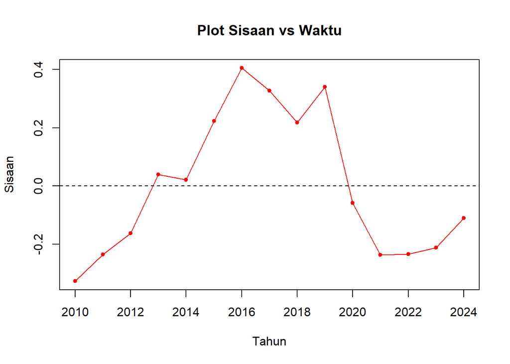

```r
# Ambil sisaan dari model
sisaan_awal <- residuals(model_awal)

# Plot sisaan terhadap waktu
plot(ipmJatim$tahun, sisaan_awal, type="o", pch=20, col="red",
     main="Plot Sisaan vs Waktu", xlab="Tahun", ylab="Sisaan")
abline(h=0, lty=2) # Garis referensi di y=0
```

Plot di atas menunjukkan pola yang **tidak acak**. Perhatikan bagaimana sisaan cenderung berkelompok: titik pertama di bawah nol, lalu naik ke atas nol, dan turun lagi. Ini adalah gejala visual yang kuat dari autokorelasi positif. Sisaan positif cenderung diikuti sisaan positif, dan sebaliknya.

#### 3.2. Diagnosis Formal (Uji Durbin-Watson)

Visual saja tidak cukup, kita butuh bukti formal. Kita gunakan Uji Durbin-Watson.

- **H0 (Hipotesis Nol)**: Tidak ada autokorelasi. Sisaan saling bebas.
- **H1 (Hipotesis Alternatif)**: Ada autokorelasi.

```r
library(lmtest)
dwtest(model_awal)
```

```
##
##  Durbin-Watson test
##
## data:  model_awal
## DW = 0.42882, p-value = 3.91e-06
## alternative hypothesis: true autocorrelation is greater than 0
```

p-value yang dihasilkan sangat kecil (3.91e-06) dan berada di bawah tingkat signifikansi 5%, artinya Tolak H0. Berarti terbukti bahwa model berautokorelasi.

### Step 4: Penanganan

#### 4.1 Metode Cochrane-Orcutt

```r
library(orcutt)
# Dengan fungsi R
model_co <- cochrane.orcutt(model_awal)
summary(model_co)
```

```
## Call:
## lm(formula = ipm ~ tahun, data = ipmJatim)
##
##                Estimate  Std. Error t value  Pr(>|t|)
## (Intercept) -1.0534e+03  7.4110e+01 -14.214 7.178e-09 ***
## tahun        5.5707e-01  3.6683e-02  15.186 3.375e-09 ***
## ---
## Signif. codes:  0 '***' 0.001 '**' 0.01 '*' 0.05 '.' 0.1 ' ' 1
##
## Residual standard error: 0.1456 on 12 degrees of freedom
## Multiple R-squared:  0.9505 ,  Adjusted R-squared:  0.9464
## F-statistic: 230.6 on 1 and 12 DF,  p-value: < 3.375e-09
##
## Durbin-Watson statistic
## (original):    0.42882 , p-value: 3.91e-06
## (transformed): 1.83151 , p-value: 2.555e-01
```

```r
rho <- model_co$rho # rho paling optimum
cat("Rho optimum:", rho)
```

```
## Rho optimum: 0.7368492
```

Setelah dilakukan koreksi menggunakan metode Cochrane-Orcutt, diperoleh model baru dengan koefisien regresi yang tetap signifikan dan residual standard error yang lebih kecil. Nilai R2 model sedikit menurun menjadi 95,05%, tetapi autokorelasi berhasil diatasi (DW = 1,8315; p > 0,05).

```r
# Dengan Perhitungan Manual
ipm.trans <- ipmJatim$ipm[-1] - ipmJatim$ipm[-12]*rho

tahun.trans <- ipmJatim$tahun[-1] - ipmJatim$tahun[-12]*rho
model_co_manual <- lm(ipm.trans~tahun.trans)

b0_co_manual <- coef(model_co_manual)[1]/(1-rho)
b1_co_manual <- coef(model_co_manual)[2]
cat("Koefisien manual Cochrane-Orcutt:\n")
```

```
## Koefisien manual Cochrane-Orcutt:
```

```r
cat("b0:", b0_co_manual, "\n")
```

```
## b0: -999.8072
```

```r
cat("b1:", b1_co_manual, "\n")
```

```
## b1: 0.5304916
```

#### 4.2 Metode hildreth-Lu

```r
#Penanganan Autokorelasi Hildreth lu
# Hildreth-Lu
hildreth.lu.func<- function(r, model){
  x <- model.matrix(model)[,-1]
  y <- model.response(model.frame(model))
  n <- length(y)
  t <- 2:n
  y <- y[t]-r*y[t-1]
  x <- x[t]-r*x[t-1]

  return(lm(y~x))
}

#Pencariab rho yang meminimumkan SSE
r <- c(seq(0.1,0.9, by= 0.1))
tab <- data.frame("rho" = r, "SSE" = sapply(r, function(i){deviance(hildreth.lu.func(i, model_awal))}))
round(tab, 4)
```

```
##   rho    SSE
## 1 0.1 0.5905
## 2 0.2 0.4932
## 3 0.3 0.4125
## 4 0.4 0.3484
## 5 0.5 0.3009
## 6 0.6 0.2699
## 7 0.7 0.2555
## 8 0.8 0.2577
## 9 0.9 0.2764
```

```r
#Rho optimal di sekitar 0.4
rOpt <- seq(0.2,0.8, by= 0.001)
tabOpt <- data.frame("rho" = rOpt, "SSE" = sapply(rOpt, function(i){deviance(hildreth.lu.func(i, model_awal))}))
print(tabOpt[order(tabOpt$SSE),])
```

```
##       rho       SSE
## 538 0.737 0.2543887
## 537 0.736 0.2543893
## 539 0.738 0.2543898
## 536 0.735 0.2543915
## 540 0.739 0.2543925
## 535 0.734 0.2543954
## 541 0.740 0.2543969
## 534 0.733 0.2544010
## 542 0.741 0.2544030
## 533 0.732 0.2544082
## 543 0.742 0.2544107
## 532 0.731 0.2544171
## 544 0.743 0.2544201
## 531 0.730 0.2544276
```

[output cut: 587 more lines]

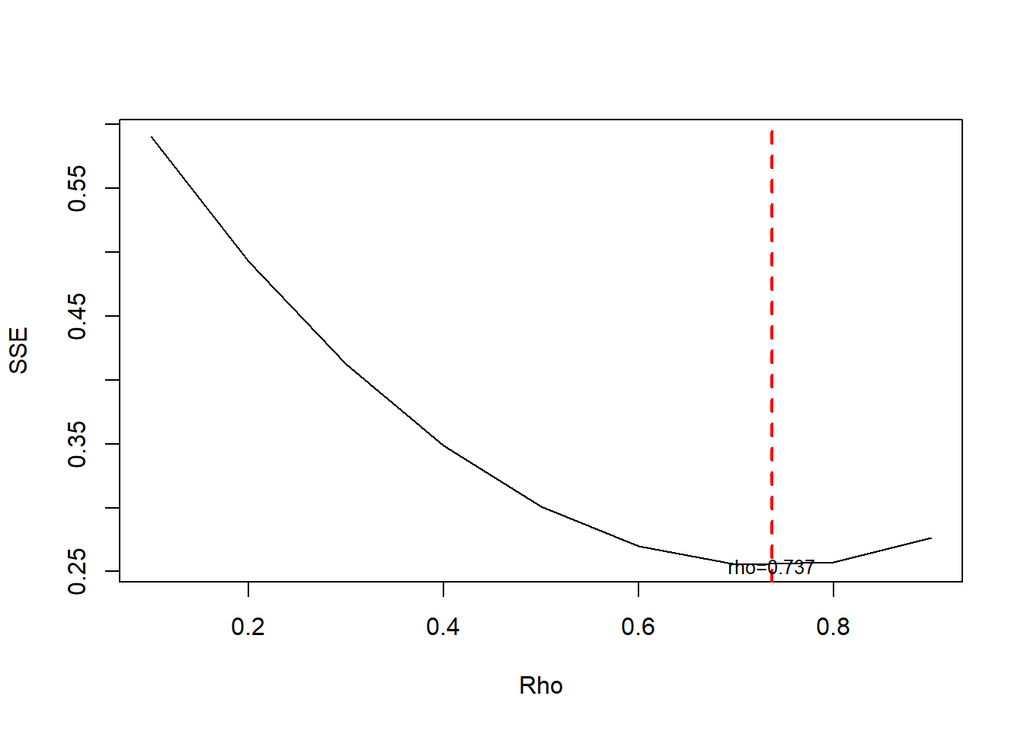

```r
#Grafik SSE optimum
par(mfrow = c(1,1))
plot(tab$SSE ~ tab$rho , type = "l", xlab = "Rho", ylab = "SSE")
abline(v = tabOpt[tabOpt$SSE==min(tabOpt$SSE),"rho"], lty = 2, col="red",lwd=2)
text(x=0.737, y=0.2543887, labels = "rho=0.737", cex = 0.8)
```

Dari tabel dan plot di atas, dapat diketahui rho optimum adalah 0.737

```r
library(HoRM)
model_hl <- hildreth.lu(ipmJatim$ipm, ipmJatim$tahun, rho = 0.737)
summary(model_hl)
```

```
##
## Call:
## lm(formula = y ~ x)
##
## Residuals:
##       Min        1Q    Median        3Q       Max
## -0.292526 -0.079010 -0.006555  0.107205  0.202834
##
## Coefficients:
##              Estimate Std. Error t value Pr(>|t|)
## (Intercept) -277.0387    19.5023  -14.21 7.23e-09 ***
## x              0.5570     0.0367   15.18 3.40e-09 ***
## ---
## Signif. codes:  0 '***' 0.001 '**' 0.01 '*' 0.05 '.' 0.1 ' ' 1
##
## Residual standard error: 0.1456 on 12 degrees of freedom
## Multiple R-squared:  0.9505, Adjusted R-squared:  0.9464
## F-statistic: 230.3 on 1 and 12 DF,  p-value: 3.399e-09
```

```r
#Transformasi Balik
cat("y = ", coef(model_hl)[1]/(1-0.341), "+", coef(model_hl)[2],"x", sep = "")
```

```
## y = -420.3926+0.5570441x
```

```r
#Deteksi autokorelasi
dwtest(model_hl)
```

```
##
##  Durbin-Watson test
##
## data:  model_hl
## DW = 1.8317, p-value = 0.2556
## alternative hypothesis: true autocorrelation is greater than 0
```

Hasil estimasi regresi Hildreth-Lu menunjukkan bahwa variabel x berpengaruh positif dan signifikan terhadap y, dengan koefisien sebesar 0.5570. Hal ini berarti setiap peningkatan 1 unit pada x akan meningkatkan nilai y sebesar 0.5570 unit. Model memiliki tingkat kecocokan yang sangat tinggi, ditunjukkan dengan nilai R2 sebesar 95,05%. Selain itu, hasil uji Durbin-Watson menghasilkan nilai DW = 1,83 dengan p-value = 0,2556, yang mengindikasikan bahwa tidak terdapat autokorelasi pada residual model.

#### Tahap 5: Evaluasi Akhir

```r
# Menghitung SSE untuk setiap model secara manual
sse_awal <- sum(residuals(model_awal)^2)
sse_co <- sum(residuals(model_co)^2)
sse_hl <- sum(residuals(model_hl)^2)

# Membuat tabel perbandingan
data.frame(
  Metode = c("Model Awal (Sakit)", "Cochrane-Orcutt (Sehat)", "Hildreth-Lu (Sehat)"),
  SSE = c(sse_awal, sse_co, sse_hl),
  DW_Statistic = c(dwtest(model_awal)$statistic, model_co$DW[3], dwtest(model_hl)$statistic)
)
```

```
##                    Metode       SSE DW_Statistic
## 1      Model Awal (Sakit) 0.8447676    0.4288209
## 2 Cochrane-Orcutt (Sehat) 2.4036228    1.8315093
## 3     Hildreth-Lu (Sehat) 0.2543887    1.8317495
```